# DRAFT/Enabling Enterprise Analytics: Part 1

A Shift in Mindset: it is time to start thinking about data literacy as a readiness problem

COL Matthew Benigni, PhD Chief Data Scientist Global Analytics Platform

07 September 2020

[figure not shown]

# Providing Feedback

This is a draft post. Much like Frederick Gauss I often mask my identity; however, I use poor spelling, grammar, and incomplete thought as my calling card. Please submit critical/constructive feedback by submitting a new issue at this [repo](https://gitlab.master.forcenex.us/gap/skope/director_posts/issues). Ensure you reference the post title, because I curate multiple posts in this repo.

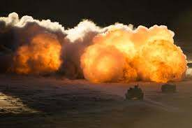

Fig. 1: National Training Center Live Fire

The special operations community has greatly improved its ability read, understand, create, and communicate data as information over the past four years. By employing highly technical military talent alongside commercial data scientists and developers to solve today’s most pressing problems, we have initiated a cultural shift which will allow us to leverage Artificial Intelligence and Machine Learning (AI/ML) at the speed of war. Our transformation strategy is built upon decades experience training and employing the worlds most skilled soldiers, except applied to the employment of new skillsets: data science and software engineering. By prioritizing repetition, progression, and collaboration we capitalize on our organizational strengths: a compelling mission, a flat innovative culture, and a commitment develop and share best practices across the force. We assert that there is nothing “SOF peculiar” about this framework, and that it can likely be applied by the general purpose force as well as other government agencies. In fact, much of our philosophy has been shaped by our inter-agency colleagues.

# A Shift In Mindset from Procurement to Readiness

As a young armor officer 22 years ago I participated in a brigade-level offensive live fire at the National Training Center in Fort Irwin, CA. Well over 100 armored vehicles safely maneuvered over complex terrain using direct fire, indirect fire, obscuration, and explosive charges to exercise the most complex operation within a heavy division, the ‘in-stride-breach’. To train a brigade combat team to that level of readiness requires a division training plan that begins with unit tactics and progressively incorporates complexity and synchronization. The Army has executed this type of training to maintain readiness for decades; we are arguably the best in the world at it. We understand the opportunity cost of introducing too much complexity too early. What type of training outcome would we expect if a heavy brigade combat team’s first training event was always the in-stride-breach? Attempting to operationalize artificial intelligence and machine learning with too much complexity too early effects desired outcomes in a manner similar fashion.

“More often than not, companies are not ready for AI. Maybe they hired their first data scientist to less-than-stellar outcomes, or maybe data literacy is not central to their culture. But the most common scenario is that they have not yet built the infrastructure to implement (and reap the benefits of) the most basic data science algorithms and operations, much less machine learning.”

[“The AI Hierarchy of Needs”](https://medium.com/hackernoon/the-ai-hierarchy-of-needs-18f111fcc007) **Monica Rogati**, Medium 2017

Monica Rogati introduced the Figure 1 in her popular Medium article [The AI Hierarchy of Needs](https://medium.com/hackernoon/the-ai-hierarchy-of-needs-18f111fcc007) (Rogati 2019). She explains that often times companies are not ready for AI and observe disappointing returns on initial efforts to resource digital transformation. She explains a hierarchy of needs starting with making data **accessible**, then prioritizing the hard work of exploring, cleaning, and enriching that data to make it **usable.** Once a company’s data is both accessible and usable, they are ready to pursue AI/ML through experimentation.

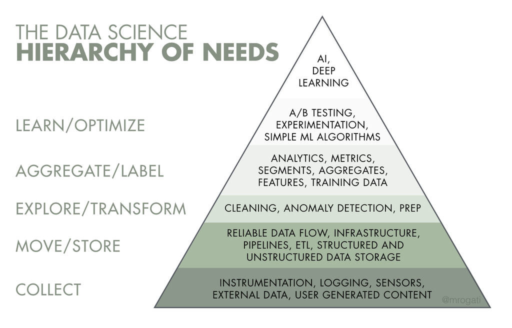

Figure 1

# Growing Organizational Digital Literacy

The Global Analytics Platform’s (GAP) charter is to make our command’s data accessible, useful, and insightful. We have prioritized our data flows and common data fabric, while focusing on areas of our commands holdings with relatively mature data pipelines to experiment and surface insights to our customers. We have used our near-term mission needs to grow our customer’s appreciation of the power of **usable data**, and observed positive change in terms of organizational digital literacy. In this series we will explain why we adopt a readiness mindset with respect to AI/ML in prioritize today’s mission problems to up-skill our organization, make smart infrastructure investments, and ultimately grow the data literacy requires to become an AI-enabled force.

**Organizational Data literacy** - an organization’s ability to read, understand, create, and communicate data as information

Within this series I will explain how the special operations community employs data science teams in support of deployed Special Operations Joint Task Forces (SOJTF). This focus on mission outcomes quickly up-skills our data science teams, grows the data literacy of our operators and analysts, and enables the enterprise to make informed infrastructure decisions that move us towards being an AI/ML-enabled force. The early result is a more responsive SOJTF, and we think this path toward increased capability has only just begun.

- Part 2: Drilling for Responsive, Relevant, Rigorous, and Reusable Analytics at the Edge
- Part 3: Enabling Next Generation PED: platforms for robust pipelines
- Part 4: Training for Torque: deliberately growing technical depth by treating fundamentals as team features

# Works Cited

Rogati, Monica. 2019. “The AI Hierarchy of Needs.” *Medium*. https://medium.com/hackernoon/the-ai-hierarchy-of-needs-18f111fcc007.